# AIML Open Challenge

## Business Understanding

As a data scientist, first we have to translate a business problem into an AI and data science solution before diving into exploratory analysis and predictive modeling:

- **Flag fraudulent transactions while also avoid misclassifying legit transactions as fraudulent** - Build predictive models to tackle a binary classification problem minimizing both false negatives (FN) and false positives (FP).
- **Detect fraudulent transactions immediately** - Build models with both low running time and good performance.
- **Understand what factors are more predictive to detect fraud; thus, they can be investigated further and more relevant data can be collected** - It’s important to not only focus on performance, but also inferences; simple models with better  
  interpreting power also have crucial roles.

**Importing relevant libraries**

```python
import numpy as np
import pandas as pd
import seaborn as sns
from matplotlib import pyplot as plt

from sklearn.linear_model import LogisticRegression
from sklearn.metrics import classification_report
from sklearn.model_selection import train_test_split

from sklearn.model_selection import KFold
from sklearn.metrics import roc_auc_score
from sklearn.ensemble import RandomForestClassifier
from sklearn.ensemble import AdaBoostClassifier
from sklearn import svm
import lightgbm as lgb
from lightgbm import LGBMClassifier
import xgboost as xgb
```

```python
data = pd.read_csv("data/creditcard.csv")
data.head()
```

|  | Time | V1 | V2 | V3 | V4 | V5 | V6 | V7 | V8 | V9 | ... | V21 | V22 | V23 | V24 | V25 | V26 | V27 | V28 | Amount | Class |
| --- | --- | --- | --- | --- | --- | --- | --- | --- | --- | --- | --- | --- | --- | --- | --- | --- | --- | --- | --- | --- | --- |
| 0 | 0.0 | -1.359807 | -0.072781 | 2.536347 | 1.378155 | -0.338321 | 0.462388 | 0.239599 | 0.098698 | 0.363787 | ... | -0.018307 | 0.277838 | -0.110474 | 0.066928 | 0.128539 | -0.189115 | 0.133558 | -0.021053 | 149.62 | 0 |
| 1 | 0.0 | 1.191857 | 0.266151 | 0.166480 | 0.448154 | 0.060018 | -0.082361 | -0.078803 | 0.085102 | -0.255425 | ... | -0.225775 | -0.638672 | 0.101288 | -0.339846 | 0.167170 | 0.125895 | -0.008983 | 0.014724 | 2.69 | 0 |
| 2 | 1.0 | -1.358354 | -1.340163 | 1.773209 | 0.379780 | -0.503198 | 1.800499 | 0.791461 | 0.247676 | -1.514654 | ... | 0.247998 | 0.771679 | 0.909412 | -0.689281 | -0.327642 | -0.139097 | -0.055353 | -0.059752 | 378.66 | 0 |
| 3 | 1.0 | -0.966272 | -0.185226 | 1.792993 | -0.863291 | -0.010309 | 1.247203 | 0.237609 | 0.377436 | -1.387024 | ... | -0.108300 | 0.005274 | -0.190321 | -1.175575 | 0.647376 | -0.221929 | 0.062723 | 0.061458 | 123.50 | 0 |
| 4 | 2.0 | -1.158233 | 0.877737 | 1.548718 | 0.403034 | -0.407193 | 0.095921 | 0.592941 | -0.270533 | 0.817739 | ... | -0.009431 | 0.798278 | -0.137458 | 0.141267 | -0.206010 | 0.502292 | 0.219422 | 0.215153 | 69.99 | 0 |

5 rows × 31 columns

## Exploratory Data Analysis

**Detecting Missing Value**

```python
data.isnull().sum().max()
```

```
0
```

There is no missing data in the entire dataset.

**Class - Target Distribution**

```python
# The classes are heavily skewed we need to solve this issue later.
print('No Frauds:', round(data['Class'].value_counts()[0]/len(data) * 100,2), '% of the dataset')
print('Frauds: ', round(data['Class'].value_counts()[1]/len(data) * 100,2), '% of the dataset')
```

```
No Frauds: 99.83 % of the dataset
Frauds:  0.17 % of the dataset
```

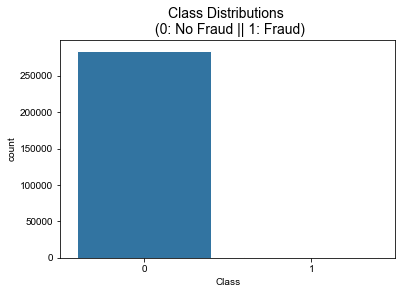

```python
plt.title('Class Distributions \n (0: No Fraud || 1: Fraud)', fontsize=14)
sns.set_style("darkgrid")
ax = sns.countplot(x="Class",data=data)
```

Notice how imbalanced is our original dataset! Most of the transactions are non-fraud. If we use this dataframe as the base for our predictive models and analysis we might get a lot of errors and our algorithms will probably overfit since it will "assume" that most transactions are not fraud. But we don't want our model to assume, we want our model to detect patterns that give signs of fraud!

**Feature Distributions**

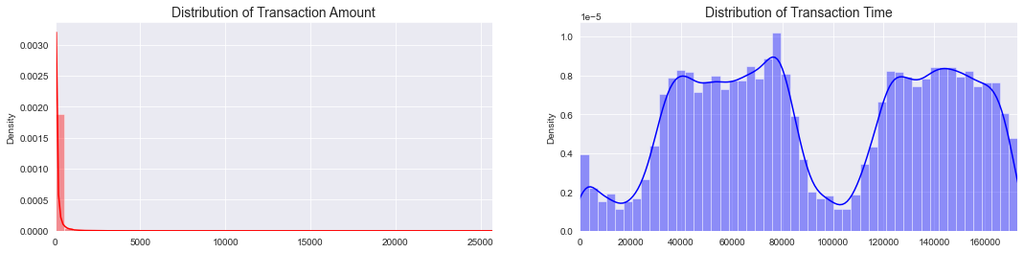

```python
fig, ax = plt.subplots(1, 2, figsize=(18,4))

amount_val = data['Amount'].values
time_val   = data['Time'].values

sns.distplot(amount_val, ax=ax[0], color='r')
ax[0].set_title('Distribution of Transaction Amount', fontsize=14)
ax[0].set_xlim([min(amount_val), max(amount_val)])

sns.distplot(time_val, ax=ax[1], color='b')
ax[1].set_title('Distribution of Transaction Time', fontsize=14)
ax[1].set_xlim([min(time_val), max(time_val)])

plt.show()
```

By seeing the distributions we can have an idea how skewed are these features. We will scale them before modeling.

**Features correlation**

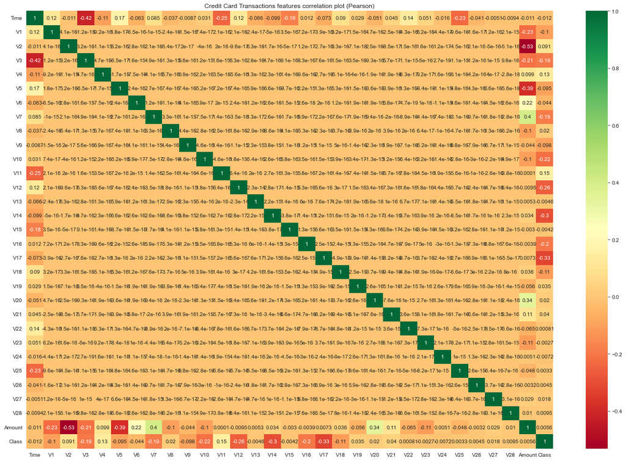

```python
# correlation gives us relation between each varibale. how much each variable is contributing.
plt.figure(figsize=(22,15))
plt.title('Credit Card Transactions features correlation plot (Pearson)')

correlation = data.corr()

sns.heatmap(correlation,annot=True,cmap="RdYlGn")
plt.show()
```

As expected, there is no notable correlation between features V1-V28. There are certain correlations between some of these features and Time (inverse correlation with V3) and Amount (direct correlation with V7 and V20, inverse correlation with V2 and V5).

**Features density plot**

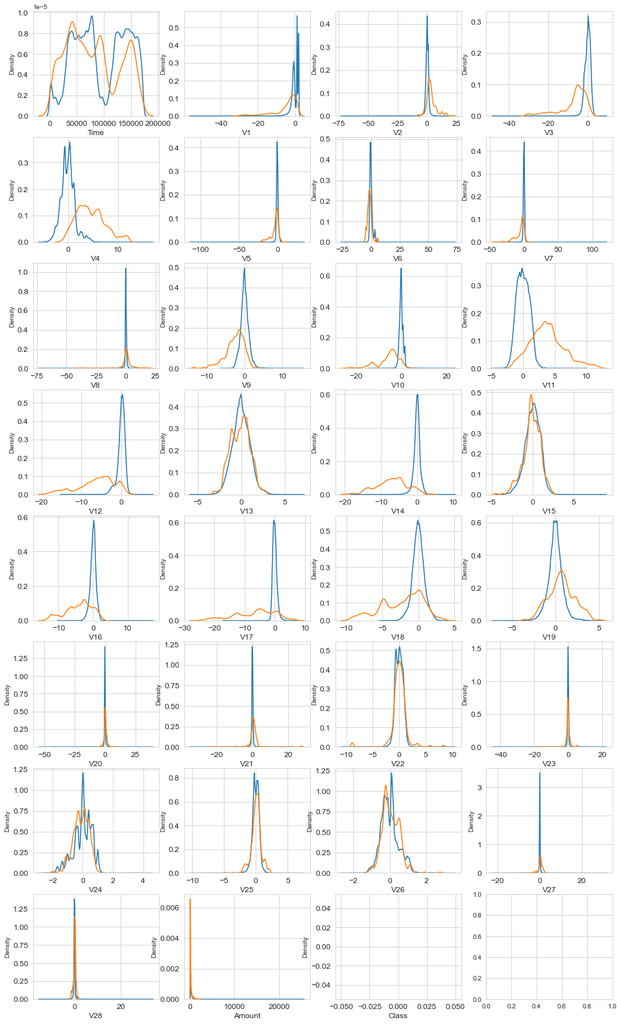

```python
var = data.columns.values

i = 0
t0 = data.loc[data['Class'] == 0]
t1 = data.loc[data['Class'] == 1]

sns.set_style('whitegrid')
plt.figure()
fig, ax = plt.subplots(8,4,figsize=(16,28))

for feature in var:
    i += 1
    plt.subplot(8,4,i)
    sns.kdeplot(t0[feature], bw_adjust=0.5,label="Class = 0")
    sns.kdeplot(t1[feature], bw_adjust=0.5,label="Class = 1")
    plt.xlabel(feature, fontsize=12)
    locs, labels = plt.xticks()
    plt.tick_params(axis='both', which='major', labelsize=12)
plt.show();
```

For some of the features we can observe a good selectivity in terms of distribution for the two values of Class: V4, V11 have clearly separated distributions for Class values 0 and 1, V12, V14, V18 are partially separated, V1, V2, V3, V10 have a quite distinct profile, whilst V25, V26, V28 have similar profiles for the two values of Class.

In general, with just few exceptions (Time and Amount), the features distribution for legitimate transactions (values of Class = 0) is centered around 0, sometime with a long queue at one of the extremities. In the same time, the fraudulent transactions (values of Class = 1) have a skewed (asymmetric) distribution.

## Data Preprocessing

**Tackling Imbalance Data: Resampling**

Since our classes are highly skewed we should make them equivalent in order to have a normal distribution of the classes.We will use Random undersampling technique. Random undersampling involves randomly selecting examples from the majority class to delete from the training dataset.

```python
X = data.iloc[:, data.columns != 'Class']
y = data.iloc[:, data.columns == 'Class']
```

```python
# Number of data points in the minority class
number_records_fraud = len(data[data.Class == 1])
fraud_indices = np.array(data[data.Class == 1].index)

# Picking the indices of the normal classes
normal_indices = data[data.Class == 0].index

# Out of the indices we picked, randomly select "x" number (number_records_fraud)
random_normal_indices = np.random.choice(normal_indices, number_records_fraud, replace = False)
random_normal_indices = np.array(random_normal_indices)

# Appending the 2 indices
under_sample_indices = np.concatenate([fraud_indices,random_normal_indices])

# Under sample dataset
under_sample_data = data.iloc[under_sample_indices,:]

X_undersample = under_sample_data.iloc[:, under_sample_data.columns != 'Class']
y_undersample = under_sample_data.iloc[:, under_sample_data.columns == 'Class']

# Showing ratio
print("Percentage of normal transactions: ", len(under_sample_data[under_sample_data.Class == 0])/len(under_sample_data))
print("Percentage of fraud transactions: ", len(under_sample_data[under_sample_data.Class == 1])/len(under_sample_data))
print("Total number of transactions in resampled data: ", len(under_sample_data))
```

```
Percentage of normal transactions:  0.5
Percentage of fraud transactions:  0.5
Total number of transactions in resampled data:  984
```

**To Prevent Data Leakage: Split the Dataset**

Data leakage is a big problem in machine learning when developing predictive models.Data leakage is when information from outside the training dataset is used to create the model.

```python
# Whole dataset
X_train, X_test, y_train, y_test = train_test_split(X,y,test_size = 0.3, random_state = 0)

print("Number transactions train dataset: ", len(X_train))
print("Number transactions test dataset: ", len(X_test))
print("Total number of transactions: ", len(X_train)+len(X_test))

# Undersampled dataset
X_train_undersample, X_test_undersample, y_train_undersample, y_test_undersample = train_test_split(X_undersample
                                                                                                   ,y_undersample
                                                                                                   ,test_size = 0.3
                                                                                                   ,random_state = 0)
print("")
print("Number transactions train dataset: ", len(X_train_undersample))
print("Number transactions test dataset: ", len(X_test_undersample))
print("Total number of transactions: ", len(X_train_undersample)+len(X_test_undersample))
```

```
Number transactions train dataset:  199364
Number transactions test dataset:  85443
Total number of transactions:  284807

Number transactions train dataset:  688
Number transactions test dataset:  296
Total number of transactions:  984
```

**Scale the Dataset**

```python
# Since most of our data has already been scaled we should scale the columns that are left to scale (Amount and Time)
from sklearn.preprocessing import  RobustScaler

# RobustScaler is less prone to outliers.
rob_scaler = RobustScaler()

X_train_undersample['scaled_amount'] = rob_scaler.fit_transform(X_train_undersample['Amount'].values.reshape(-1,1))
X_train_undersample['scaled_time']   = rob_scaler.fit_transform(X_train_undersample['Time'].values.reshape(-1,1))
```

```python
X_train_undersample.drop(['Time','Amount'], axis=1, inplace=True)

scaled_amount = X_train_undersample['scaled_amount']
scaled_time   = X_train_undersample['scaled_time']

X_train_undersample.drop(['scaled_amount', 'scaled_time'], axis=1, inplace=True)
X_train_undersample.insert(0, 'scaled_amount', scaled_amount)
X_train_undersample.insert(1, 'scaled_time', scaled_time)
```

```python
X_test_undersample['scaled_amount'] = rob_scaler.transform(X_test_undersample['Amount'].values.reshape(-1,1))
X_test_undersample['scaled_time']   = rob_scaler.transform(X_test_undersample['Time'].values.reshape(-1,1))
```

```python
X_test_undersample.drop(['Time','Amount'], axis=1, inplace=True)

scaled_amount = X_test_undersample['scaled_amount']
scaled_time   = X_test_undersample['scaled_time']

X_test_undersample.drop(['scaled_amount', 'scaled_time'], axis=1, inplace=True)
X_test_undersample.insert(0, 'scaled_amount', scaled_amount)
X_test_undersample.insert(1, 'scaled_time', scaled_time)
```

Thus, Amount and Time columns are Scaled!

## Modeling

In the modeling part, I used four algorithms: logistic regression, random forest, xgboost and light gradient boosting machine.

**Define predictors and target values** Let's define the predictor features and the target features. Categorical features, if any, are also defined. In our case, there are no categorical feature.

```python
target = 'Class'
predictors = ['scaled_amount','scaled_time','V1', 'V2', 'V3', 'V4', 'V5', 'V6', 'V7', 'V8', 'V9', 'V10',\
       'V11', 'V12', 'V13', 'V14', 'V15', 'V16', 'V17', 'V18', 'V19',\
       'V20', 'V21', 'V22', 'V23', 'V24', 'V25', 'V26', 'V27', 'V28']
```

**Logistic Regression**

```python
lr = LogisticRegression(max_iter=10000)
```

```python
lr.fit(X_train_undersample, y_train_undersample.values)
```

```
LogisticRegression(max_iter=10000)
```

*Performance of the Model*

```python
prediction = lr.predict(X_test_undersample)
```

```python
print(classification_report(y_test_undersample, prediction))
```

```
              precision    recall  f1-score   support

           0       0.92      0.99      0.95       149
           1       0.99      0.92      0.95       147

    accuracy                           0.95       296
   macro avg       0.95      0.95      0.95       296
weighted avg       0.95      0.95      0.95       296
```

The Accuracy score obtained for the test set is 0.95.

```python
roc_auc_score(y_test_undersample, prediction)
```

```
0.9524722640734146
```

The ROC-AUC score obtained for the test set is 0.952.

**RandomForestClassifier**

```python
RFC_METRIC     = 'gini'  #metric used for RandomForrestClassifier
NUM_ESTIMATORS = 100     #number of estimators used for RandomForrestClassifier
NO_JOBS        = 4       #number of parallel jobs used for RandomForrestClassifier

#TRAIN/VALIDATION/TEST SPLIT

TEST_SIZE = 0.20 # test size using_train_test_split

#CROSS-VALIDATION
NUMBER_KFOLDS = 5 #number of KFolds for cross-validation

RANDOM_STATE = 2018

MAX_ROUNDS = 1000 #lgb iterations
EARLY_STOP = 50 #lgb early stop
OPT_ROUNDS = 1000  #To be adjusted based on best validation rounds
VERBOSE_EVAL = 50 #Print out metric result

IS_LOCAL = False
```

```python
rf =  RandomForestClassifier(n_jobs=NO_JOBS,
                             random_state=RANDOM_STATE,
                             criterion=RFC_METRIC,
                             n_estimators=NUM_ESTIMATORS,
                             verbose=False)
```

```python
rf.fit(X_train_undersample, y_train_undersample.values)
```

```
RandomForestClassifier(n_jobs=4, random_state=2018, verbose=False)
```

*Performance of the Model*

```python
prediction = rf.predict(X_test_undersample)
```

```python
print(classification_report(y_test_undersample, prediction))
```

```
              precision    recall  f1-score   support

           0       0.91      0.96      0.93       149
           1       0.96      0.90      0.93       147

    accuracy                           0.93       296
   macro avg       0.93      0.93      0.93       296
weighted avg       0.93      0.93      0.93       296
```

The Accuracy score obtained for the test set is 0.93.

```python
roc_auc_score(y_test_undersample, prediction)
```

```
0.9288453636488153
```

The ROC-AUC score obtained for the test set is 0.928.

*Variable Importance Plot*

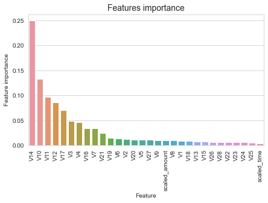

```python
tmp = pd.DataFrame({'Feature': predictors, 'Feature importance': rf.feature_importances_})
tmp = tmp.sort_values(by='Feature importance',ascending=False)
plt.figure(figsize = (7,4))
plt.title('Features importance',fontsize=14)
s = sns.barplot(x='Feature',y='Feature importance',data=tmp)
s.set_xticklabels(s.get_xticklabels(),rotation=90)
plt.show()
```

**XGBoost**

```python
# Prepare the train and valid datasets
dtrain = xgb.DMatrix(X_train_undersample, y_train_undersample.values)

dtest  = xgb.DMatrix(X_test_undersample, y_test_undersample.values)

#What to monitor (in this case, **train** )
watchlist = [(dtrain, 'train')]

# Set xgboost parameters
params = {}
params['objective']         = 'binary:logistic'
params['eta']               = 0.039
params['silent']            = True
params['max_depth']         = 2
params['subsample']         = 0.8
params['colsample_bytree']  = 0.9
params['eval_metric']       = 'auc'
params['random_state']      = RANDOM_STATE
```

```python
model = xgb.train(params,
                dtrain,
                MAX_ROUNDS,
                watchlist,
                early_stopping_rounds=EARLY_STOP,
                maximize=True,
                verbose_eval=VERBOSE_EVAL)
```

[output not shown]

*Performance of the Model*

```python
prediction = model.predict(dtest)
```

```python
from sklearn.metrics import roc_curve, auc
```

```python
def Find_Optimal_Cutoff(target, predicted):
    """ Find the optimal probability cutoff point for a classification model related to event rate
    Parameters
    ----------
    target : Matrix with dependent or target data, where rows are observations

    predicted : Matrix with predicted data, where rows are observations

    Returns
    -------
    list type, with optimal cutoff value

    """
    fpr, tpr, threshold = roc_curve(target, predicted)
    i = np.arange(len(tpr))
    roc = pd.DataFrame({'tf' : pd.Series(tpr-(1-fpr), index=i), 'threshold' : pd.Series(threshold, index=i)})
    roc_t = roc.iloc[(roc.tf-0).abs().argsort()[:1]]

    return list(roc_t['threshold'])
```

```python
threshold = Find_Optimal_Cutoff(y_test_undersample, prediction)
print(threshold)
```

```
[0.41208595037460327]
```

```python
prediction_binary = prediction
```

```python
prediction_binary[prediction_binary > threshold]   = 1
prediction_binary[prediction_binary <= threshold]  = 0
```

```python
print(classification_report(y_test_undersample, prediction_binary))
```

```
              precision    recall  f1-score   support

           0       0.93      0.95      0.94       149
           1       0.95      0.93      0.94       147

    accuracy                           0.94       296
   macro avg       0.94      0.94      0.94       296
weighted avg       0.94      0.94      0.94       296
```

The Accuracy score obtained for the test set is 0.94.

```python
roc_auc_score(y_test_undersample, prediction)
```

```
0.9390951011276994
```

The ROC-AUC score obtained for the test set is 0.939.

*Variable Importance Plot*

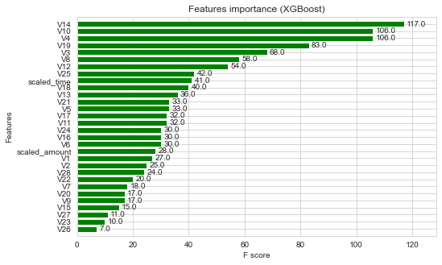

```python
fig, (ax) = plt.subplots(ncols=1, figsize=(8,5))
xgb.plot_importance(model, height=0.8, title="Features importance (XGBoost)", ax=ax, color="green")
plt.show()
```

**LightGBM**

```python
params = {
          'boosting_type':    'gbdt',
          'objective':        'binary',
          'metric':           'auc',
          'learning_rate':     0.05,
          'num_leaves':        7,   # we should let it be smaller than 2^(max_depth)
          'max_depth':         4,   # -1 means no limit
          'min_child_samples': 100, # Minimum number of data need in a child(min_data_in_leaf)
          'max_bin':           100, # Number of bucketed bin for feature values
          'subsample':         0.9, # Subsample ratio of the training instance.
          'subsample_freq':    1,   # frequence of subsample, <=0 means no enable
          'colsample_bytree':  0.7, # Subsample ratio of columns when constructing each tree.
          'min_child_weight':  0,   # Minimum sum of instance weight(hessian) needed in a child(leaf)
          'min_split_gain':    0,   # lambda_l1, lambda_l2 and min_gain_to_split to regularization
          'nthread':           8,
          'verbose':           0,
          'scale_pos_weight':  150, # because training data is extremely unbalanced
         }
```

```python
dtrain = lgb.Dataset(X_train_undersample.values,
                     label        = y_train_undersample.values,
                     feature_name = predictors)
```

```python
evals_results = {}

model = lgb.train(params,
                  dtrain,
                  valid_sets            = [dtrain ],
                  valid_names           = ['train'],
                  evals_result          = evals_results,
                  num_boost_round       = MAX_ROUNDS,
                  early_stopping_rounds = 2*EARLY_STOP,
                  verbose_eval          =    VERBOSE_EVAL,
                  feval                 = None)
```

[output not shown]

[output cut: 897 more lines]

[output not shown]

*Performance of the Model*

```python
prediction = model.predict(X_test_undersample.values)
```

```python
from sklearn.metrics import roc_curve, auc
```

```python
def Find_Optimal_Cutoff(target, predicted):
    """ Find the optimal probability cutoff point for a classification model related to event rate
    Parameters
    ----------
    target : Matrix with dependent or target data, where rows are observations

    predicted : Matrix with predicted data, where rows are observations

    Returns
    -------
    list type, with optimal cutoff value

    """
    fpr, tpr, threshold = roc_curve(target, predicted)
    i = np.arange(len(tpr))
    roc = pd.DataFrame({'tf' : pd.Series(tpr-(1-fpr), index=i), 'threshold' : pd.Series(threshold, index=i)})
    roc_t = roc.iloc[(roc.tf-0).abs().argsort()[:1]]

    return list(roc_t['threshold'])
```

```python
threshold = Find_Optimal_Cutoff(y_test_undersample, prediction)
print(threshold)
```

```
[0.9027551363852085]
```

```python
prediction_binary = prediction
```

```python
prediction_binary[prediction_binary > threshold]   = 1
prediction_binary[prediction_binary <= threshold]  = 0
```

```python
print(classification_report(y_test_undersample, prediction_binary))
```

```
              precision    recall  f1-score   support

           0       0.93      0.91      0.92       149
           1       0.91      0.93      0.92       147

    accuracy                           0.92       296
   macro avg       0.92      0.92      0.92       296
weighted avg       0.92      0.92      0.92       296
```

The Accuracy score obtained for the test set is 0.92.

```python
roc_auc_score(y_test_undersample, prediction)
```

```
0.91896087293978
```

The ROC-AUC score obtained for the test set is 0.918.

*Variable Importance Plot*

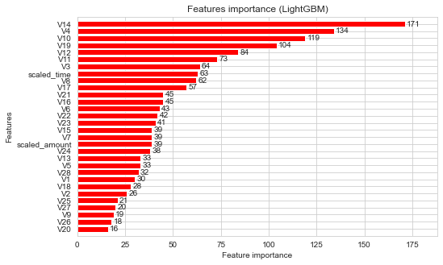

```python
fig, (ax) = plt.subplots(ncols=1, figsize=(8,5))
lgb.plot_importance(model, height=0.8, title="Features importance (LightGBM)", ax=ax,color="red")
plt.show()
```

## Business Implementation:

In practice, we need to combine machine learning and automation with direct customer contact to identify and address potential fraud. Our models should trigger a follow-up action like a text message, notification on cellphone application, or phone call to the customer.

Here is my simplified hypothetical implementation strategy based on models' predicted probability and transaction amount with assistances from customers:

```python
+--------------------------+------------------------------------------+------------------------------------------+
|                          | High probability being a fraud           | Low probability being a fraud            |
+--------------------------+------------------------------------------+------------------------------------------+
| High-cost transactions   | Block and confirm                        | Let through and confirm                  |
+--------------------------+------------------------------------------+------------------------------------------+
| Medium-cost transactions | Let through and confirm                  | Let through and flag risk on application |
+--------------------------+------------------------------------------+------------------------------------------+
| Low-cost transactions    | Let through and flag risk on application | Let through and flag risk on application |
+--------------------------+------------------------------------------+------------------------------------------+
```